# Astrid Barreras

# Load libraries

```r
library(dplyr)
```

```r
library(Lahman)
library(ggplot2)
library(reshape2)
library(corrplot)
library(knitr)
library(tidyverse)
library(caret)
```

## Read in Data

I am using Teams data from the Lahman R package. Documentation for this dataset can be found [in Lahmans website](https://www.dropbox.com/scl/fi/9i2nhlskvfkqy7mbuqem7/readme2023.txt?rlkey=odnwx7ujztm0z4ob8dmggfcr0&dl=0).

```r
# Load datasets from package
data(package = "Lahman")
```

```r
# Load Teams dataset
data("Teams")
```

```r
# Create a data frame with the column names and descriptions
data_description <- data.frame(
  teams_col = c("yearID", "lgID", "teamID", "franchID", "divID", "Rank", "G", "GHome", "W", "L",
             "DivWin", "WCWin", "LgWin", "WSWin", "R", "AB", "H", "2B", "3B", "HR", "BB", "SO",
             "SB", "CS", "HBP", "SF", "RA", "ER", "ERA", "CG", "SHO", "SV", "IPOuts", "HA", "HRA",
             "BBA", "SOA", "E", "DP", "FP", "name", "park", "attendance", "BPF", "PPF", "teamIDBR",
             "teamIDlahman45", "teamIDretro"),
  col_des = c("Year", "League", "Team", "Franchise (links to TeamsFranchise table)",
                  "Team's division", "Position in final standings", "Games played",
                  "Games played at home", "Wins", "Losses", "Division Winner (Y or N)",
                  "Wild Card Winner (Y or N)", "League Champion (Y or N)",
                  "World Series Winner (Y or N)", "Runs scored", "At bats", "Hits by batters",
                  "Doubles", "Triples", "Home runs by batters", "Walks by batters",
                  "Strikeouts by batters", "Stolen bases", "Caught stealing", "Batters hit by pitch",
                  "Sacrifice flies", "Opponents runs scored", "Earned runs allowed",
                  "Earned run average", "Complete games", "Shutouts", "Saves",
                  "Outs Pitched (innings pitched x 3)", "Hits allowed", "Home runs allowed",
                  "Walks allowed", "Strikeouts by pitchers", "Errors", "Double Plays",
                  "Fielding percentage", "Team's full name", "Name of team's home ballpark",
                  "Home attendance total", "Three-year park factor for batters",
                  "Three-year park factor for pitchers", "Team ID used by Baseball Reference website",
                  "Team ID used in Lahman database version 4.5", "Team ID used by Retrosheet")
)

# Display the table
kable(data_description, col.names = c("Column", "Description"), caption = "TEAMS Data Description")
```

TEAMS Data Description

| Column | Description |
| --- | --- |
| yearID | Year |
| lgID | League |
| teamID | Team |
| franchID | Franchise (links to TeamsFranchise table) |
| divID | Team’s division |
| Rank | Position in final standings |
| G | Games played |
| GHome | Games played at home |
| W | Wins |
| L | Losses |
| DivWin | Division Winner (Y or N) |
| WCWin | Wild Card Winner (Y or N) |
| LgWin | League Champion (Y or N) |
| WSWin | World Series Winner (Y or N) |
| R | Runs scored |
| AB | At bats |
| H | Hits by batters |
| 2B | Doubles |
| 3B | Triples |
| HR | Home runs by batters |
| BB | Walks by batters |
| SO | Strikeouts by batters |
| SB | Stolen bases |
| CS | Caught stealing |
| HBP | Batters hit by pitch |
| SF | Sacrifice flies |
| RA | Opponents runs scored |
| ER | Earned runs allowed |
| ERA | Earned run average |
| CG | Complete games |
| SHO | Shutouts |
| SV | Saves |
| IPOuts | Outs Pitched (innings pitched x 3) |
| HA | Hits allowed |
| HRA | Home runs allowed |
| BBA | Walks allowed |
| SOA | Strikeouts by pitchers |
| E | Errors |
| DP | Double Plays |
| FP | Fielding percentage |
| name | Team’s full name |
| park | Name of team’s home ballpark |
| attendance | Home attendance total |
| BPF | Three-year park factor for batters |
| PPF | Three-year park factor for pitchers |
| teamIDBR | Team ID used by Baseball Reference website |
| teamIDlahman45 | Team ID used in Lahman database version 4.5 |
| teamIDretro | Team ID used by Retrosheet |

# View of the Data

```r
# Show the first 6 rows of the dataset
head(Teams)
```

```
##   yearID lgID teamID franchID divID Rank  G Ghome  W  L DivWin WCWin LgWin
## 1   1871   NA    BS1      BNA  <NA>    3 31    NA 20 10   <NA>  <NA>     N
## 2   1871   NA    CH1      CNA  <NA>    2 28    NA 19  9   <NA>  <NA>     N
## 3   1871   NA    CL1      CFC  <NA>    8 29    NA 10 19   <NA>  <NA>     N
## 4   1871   NA    FW1      KEK  <NA>    7 19    NA  7 12   <NA>  <NA>     N
## 5   1871   NA    NY2      NNA  <NA>    5 33    NA 16 17   <NA>  <NA>     N
## 6   1871   NA    PH1      PNA  <NA>    1 28    NA 21  7   <NA>  <NA>     Y
##   WSWin   R   AB   H X2B X3B HR BB SO SB CS HBP SF  RA  ER  ERA CG SHO SV
## 1  <NA> 401 1372 426  70  37  3 60 19 73 16  NA NA 303 109 3.55 22   1  3
## 2  <NA> 302 1196 323  52  21 10 60 22 69 21  NA NA 241  77 2.76 25   0  1
## 3  <NA> 249 1186 328  35  40  7 26 25 18  8  NA NA 341 116 4.11 23   0  0
## 4  <NA> 137  746 178  19   8  2 33  9 16  4  NA NA 243  97 5.17 19   1  0
## 5  <NA> 302 1404 403  43  21  1 33 15 46 15  NA NA 313 121 3.72 32   1  0
## 6  <NA> 376 1281 410  66  27  9 46 23 56 12  NA NA 266 137 4.95 27   0  0
##   IPouts  HA HRA BBA SOA   E DP    FP                    name
```

[output cut: 20 more lines]

```r
# Show structure of the dataset
str(Teams)
```

```
## 'data.frame':    3045 obs. of  48 variables:
##  $ yearID        : int  1871 1871 1871 1871 1871 1871 1871 1871 1871 1872 ...
##  $ lgID          : Factor w/ 7 levels "AA","AL","FL",..: 4 4 4 4 4 4 4 4 4 4 ...
##  $ teamID        : Factor w/ 149 levels "ALT","ANA","ARI",..: 24 31 39 56 90 97 111 136 142 8 ...
##  $ franchID      : Factor w/ 120 levels "ALT","ANA","ARI",..: 13 36 25 56 70 85 91 109 77 9 ...
##  $ divID         : chr  NA NA NA NA ...
##  $ Rank          : int  3 2 8 7 5 1 9 6 4 2 ...
##  $ G             : int  31 28 29 19 33 28 25 29 32 58 ...
##  $ Ghome         : int  NA NA NA NA NA NA NA NA NA NA ...
##  $ W             : int  20 19 10 7 16 21 4 13 15 35 ...
##  $ L             : int  10 9 19 12 17 7 21 15 15 19 ...
##  $ DivWin        : chr  NA NA NA NA ...
##  $ WCWin         : chr  NA NA NA NA ...
##  $ LgWin         : chr  "N" "N" "N" "N" ...
##  $ WSWin         : chr  NA NA NA NA ...
```

[output cut: 34 more lines]

All variables in the dataset are set to their appropriate data types.

# Missing Values

```r
# Get columns with missing values and their percentage of missing data
missing_data <- colMeans(is.na(Teams)) * 100
missing_data<- missing_data[missing_data > 0]

# Display the results
print(missing_data)
```

```
##      divID      Ghome     DivWin      WCWin      LgWin      WSWin         SO
## 49.8193760 13.1034483 50.7389163 71.6256158  0.9195402 11.7241379  0.5254516
##         SB         CS        HBP         SF       park attendance
##  4.1050903 27.2906404 38.0295567 50.6075534  1.1165846  9.1625616
```

```r
# Deleting columns with > 50% missing data
Teams <- Teams %>% select(-divID, -SF, - DivWin, -WCWin)
```

```r
# Checking to see if the above columns were deleted
names(Teams)
```

```
##  [1] "yearID"         "lgID"           "teamID"         "franchID"
##  [5] "Rank"           "G"              "Ghome"          "W"
##  [9] "L"              "LgWin"          "WSWin"          "R"
## [13] "AB"             "H"              "X2B"            "X3B"
## [17] "HR"             "BB"             "SO"             "SB"
## [21] "CS"             "HBP"            "RA"             "ER"
## [25] "ERA"            "CG"             "SHO"            "SV"
## [29] "IPouts"         "HA"             "HRA"            "BBA"
## [33] "SOA"            "E"              "DP"             "FP"
## [37] "name"           "park"           "attendance"     "BPF"
## [41] "PPF"            "teamIDBR"       "teamIDlahman45" "teamIDretro"
```

Columns were successfully deleted.

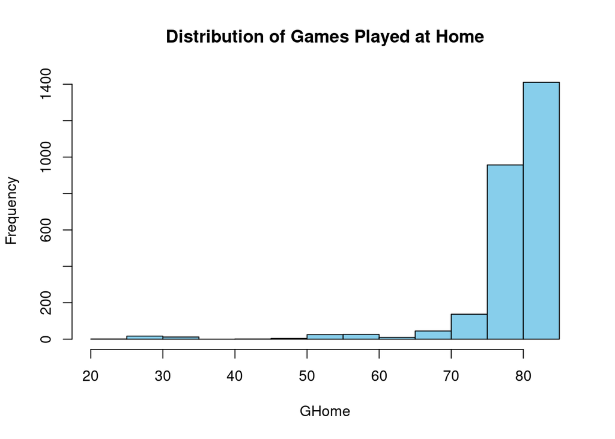

```r
# Visualize distribution of Games played at home (GHome)
hist(Teams$Ghome, main = "Distribution of Games Played at Home", xlab = "GHome", col = "skyblue")
```

```r
# Imputation of Ghome missing data with median
Teams$Ghome[is.na(Teams$Ghome)] <- median(Teams$Ghome, na.rm = TRUE)
```

```r
# Check if column has any missing values
any(is.na(Teams$Ghome))
```

```
## [1] FALSE
```

This shows that the imputation method worked.

```r
# Subset rows with missing LgWin values
missing_lgwin <- Teams[is.na(Teams$LgWin), ]

# View the subset
print(missing_lgwin)
```

```
##      yearID lgID teamID franchID Rank   G Ghome  W  L LgWin WSWin   R   AB    H
## 2154   1994   AL    BAL      BAL    2 112    55 63 49  <NA>  <NA> 589 3856 1047
## 2155   1994   AL    BOS      BOS    4 115    64 54 61  <NA>  <NA> 552 3940 1038
## 2156   1994   AL    CAL      ANA    4 115    63 47 68  <NA>  <NA> 543 3943 1042
## 2157   1994   AL    CHA      CHW    1 113    53 67 46  <NA>  <NA> 633 3942 1133
## 2158   1994   AL    CLE      CLE    2 113    51 66 47  <NA>  <NA> 679 4022 1165
## 2159   1994   AL    DET      DET    5 115    58 53 62  <NA>  <NA> 652 3955 1048
## 2160   1994   AL    KCA      KCR    3 115    59 64 51  <NA>  <NA> 574 3911 1051
## 2161   1994   AL    MIN      MIN    4 113    59 53 60  <NA>  <NA> 594 3952 1092
## 2162   1994   AL    ML4      MIL    5 115    56 53 62  <NA>  <NA> 547 3978 1045
## 2163   1994   AL    NYA      NYY    1 113    57 70 43  <NA>  <NA> 670 3986 1155
## 2164   1994   AL    OAK      OAK    2 114    56 51 63  <NA>  <NA> 549 3885 1009
## 2165   1994   AL    SEA      SEA    3 112    44 49 63  <NA>  <NA> 569 3883 1045
## 2166   1994   AL    TEX      TEX    1 114    63 52 62  <NA>  <NA> 613 3983 1114
## 2167   1994   AL    TOR      TOR    3 115    59 55 60  <NA>  <NA> 566 3962 1064
```

[output cut: 101 more lines]

Missing data for LgWin is only associated with 1994. In 1994, MLB players went on strike and it cut the season short.

```r
# Imputation of LgWin missing data with "N"
Teams$LgWin[is.na(Teams$LgWin)] <- "N"
```

Imputation of LgWin’s missing values is done with “N” given the unique historical context, as there were no league winners that year.

```r
# Check if column has any missing values
any(is.na(Teams$LgWin))
```

```
## [1] FALSE
```

This shows that the imputation method worked.

```r
# Subset rows with missing WSWin values
missing_wsw <- Teams[is.na(Teams$WSWin), ]

# Count missing WSWin by yearID in table form
table(missing_wsw$yearID)
```

```
##
## 1871 1872 1873 1874 1875 1876 1877 1878 1879 1880 1881 1882 1883 1884 1890 1891
##    9   11    9    8   13    8    6    6    8    8    8   14   16   12    8   17
## 1892 1893 1894 1895 1896 1897 1898 1899 1900 1901 1902 1904 1914 1915 1994
##   12   12   12   12   12   12   12   12    8   16   16   16    8    8   28
```

Missing data for WSWin is associated with some historical context. First, WSWin was not tracked before 1903 since World Series was not yet established. Second, no World Series was held in 1904 due to disputes between the leagues. Third, in 1994, MLB players went on strike and no World Series was held. Lastly, data missing for 1914 and 1915 could be due to inconsistencies in data tracking.

```r
# Imputation of WSWin's missing data with "N"
Teams$WSWin[is.na(Teams$WSWin) & Teams$yearID < 1903] <- "N"
Teams$WSWin[is.na(Teams$WSWin) & Teams$yearID == 1904] <- "N"
Teams$WSWin[is.na(Teams$WSWin) & Teams$yearID == 1994] <- "N"
Teams$WSWin[is.na(Teams$WSWin) & Teams$yearID %in% c(1914, 1915)] <- "N"
```

Imputation of missing values is done with “N” given the historical context described above.

```r
# Check if column has any missing values
any(is.na(Teams$WSWin))
```

```
## [1] FALSE
```

This shows that the imputation method worked.

```r
# Subset rows with missing SO values
missing_so <- Teams[is.na(Teams$SO), ]

# Count missing SO by yearID in table form
table(missing_so$yearID)
```

```
##
## 1911 1912
##    8    8
```

There are only two years with missing values for SO, this could be due to inconsistencies in tracking the data.

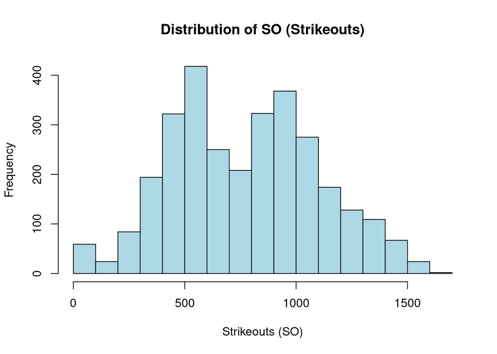

```r
# Histogram to check the distribution of SO
hist(Teams$SO, main = "Distribution of SO (Strikeouts)", xlab = "Strikeouts (SO)", col = "lightblue", breaks = 20)
```

```r
# Imputation of missing SO values with the mean SO for 1911 and 1912
Teams$SO[is.na(Teams$SO) & Teams$yearID == 1911] <- mean(Teams$SO[Teams$yearID == 1911], na.rm = TRUE)
Teams$SO[is.na(Teams$SO) & Teams$yearID == 1912] <- mean(Teams$SO[Teams$yearID == 1912], na.rm = TRUE)
```

```r
# Check if column has any missing values
any(is.na(Teams$SO))
```

```
## [1] FALSE
```

This shows that the imputation method worked.

```r
# Subset rows with missing park values
missing_park <- Teams[is.na(Teams$park), ]

# Count missing park by yearID
table(missing_park$yearID)
```

```
##
## 1884 1890 1914 1915
##   12    8    7    7
```

Missing data for park could be due to inconsistencies in tracking the data point.

```r
# Imputation of missing park values with "Unknown"
Teams$park[is.na(Teams$park)] <- "Unknown"
```

Since the parks are unknown, imputation is done with “unknown”.

```r
# Check if column has any missing values
any(is.na(Teams$park))
```

```
## [1] FALSE
```

This shows that the imputation method worked.

```r
# Subset rows with missing SB values
missing_sb <- Teams[is.na(Teams$SB), ]

# Count missing SB by yearID
table(missing_sb$yearID)
```

```
##
## 1872 1876 1877 1878 1879 1880 1881 1882 1883 1884 1885
##    2    8    6    6    8    8    8   14   16   33   16
```

SB missing data is associated with years prior to 1886, which is consistent with when MLB began tracking SB.

```r
# Filter dataset to include only years < 1886
Teams_SB <- Teams[!(Teams$yearID < 1886 & is.na(Teams$SB)), ]
```

The best method is to filter out the NA values in SB, since imputation with 0, mean, median, or mode would produce inaccurate data. This was saved to a new df so that the Teams df could continue to be analyzed. A complete update to Teams df will be made at the end.

```r
# Subset rows with missing attendance values
missing_att <- Teams[is.na(Teams$attendance), ]

# Count missing attendance by yearID
table(missing_att$yearID)
```

```
##
## 1871 1872 1873 1874 1875 1876 1877 1878 1879 1880 1881 1882 1883 1884 1885 1886
##    9   11    9    8   13    8    6    6    8    8    8   14   16   33   16   16
## 1887 1888 1889 1890 1891 1914 1915
##   16   16   16   17    9    8    8
```

```r
# Filter dataset to exclude rows with missing attendance in years < 1892, 1914, and 1915
Teams_attendance <- Teams[!(Teams$yearID < 1892 & is.na(Teams$attendance)) &
                                !(Teams$yearID %in% c(1914, 1915) & is.na(Teams$attendance)), ]
```

Excluding the years with inconsistent data instead of imputation with 0, mean, median, or mode since the latter would produce inaccurate data. This was saved to a new df so that the Teams df could continue to be analyzed. A complete update to Teams df will be made at the end.

```r
# Subset rows with missing CS values
missing_cs <- Teams[is.na(Teams$CS), ]

# Count missing CS by yearID
table(missing_cs$yearID)
```

```
##
## 1872 1875 1876 1877 1878 1879 1880 1881 1882 1883 1884 1885 1886 1887 1888 1889
##    1    1    8    6    6    8    8    8   14   16   33   16   16   16   16   16
## 1890 1891 1892 1893 1894 1895 1896 1897 1898 1899 1900 1901 1902 1903 1904 1905
##   25   17   12   12   12   12   12   12   12   12    8   16   16   16   16   16
## 1906 1907 1908 1909 1910 1911 1912 1913 1914 1915 1916 1917 1918 1919 1926 1927
##   16   16   16   16   16   16   16   16   16    8   16   16   16   16    8    8
## 1928 1929 1930 1931 1932 1933 1934 1935 1936 1937 1938 1939 1940 1941 1942 1943
##    8    8    8    8    8    8    8    8    8    8    8    8    8    8    8    8
## 1944 1945 1946 1947 1948 1949 1950
##    8    8    8    8    8    8    8
```

CS missing data is associated with years prior to 1951, which is consistent with when MLB began tracking CS.

```r
# Filter out rows where CS is NA
Teams_CS <- Teams %>% filter(!is.na(CS))
```

The best method is to filter out the NA values in CS, since imputation with 0, mean, median, or mode would produce inaccurate data. This was saved to a new df so that the Teams df could continue to be analyzed. A complete update to Teams df will be made at the end.

```r
# Subset rows with missing HBP values
missing_hbp <- Teams[is.na(Teams$HBP), ]

# Count missing HBP by yearID
table(missing_hbp$yearID)
```

```
##
## 1871 1872 1873 1874 1875 1876 1877 1878 1879 1880 1881 1882 1883 1884 1885 1886
##    9   11    9    8   13    8    6    6    8    8    8   14   16   20    8    8
## 1911 1912 1913 1914 1915 1916 1917 1918 1919 1920 1921 1922 1923 1924 1925 1926
##   16   16   16   24   24   16   16   16   16   16   16   16   16   16   16   16
## 1927 1928 1929 1930 1931 1932 1933 1934 1935 1936 1937 1938 1939 1940 1941 1942
##   16   16   16   16   16   16   16   16   16   16   16   16   16   16   16   16
## 1943 1944 1945 1946 1947 1948 1949 1950 1951 1952 1953 1954 1955 1956 1957 1958
##   16   16   16   16   16   16   16   16   16   16   16   16   16   16   16   16
## 1959 1960 1961 1962 1963 1964 1965 1966 1967 1968 1969
##   16   16   18   20   20   20   20   20   20   20   24
```

HBP missing data is associated with years prior to 1970, which is consistent with when MLB began tracking HBP.

```r
# Filter out rows where HBP is NA
Teams_HBP <- Teams %>% filter(!is.na(HBP))
```

```r
# Create a dataset with all filters above
Teams_filtered <- Teams %>%
  filter(!(yearID < 1892 & is.na(attendance)) &
         !(yearID %in% c(1914, 1915) & is.na(attendance)) &
         !(yearID < 1886 & is.na(SB)) &
         !is.na(CS) &
         !is.na(HBP))
```

```r
# Check if column has any missing values
any(is.na(Teams_filtered))
```

```
## [1] FALSE
```

All the removing of columns, excluding of missing values and imputations worked.

```r
summary(Teams_filtered)
```

```
##      yearID     lgID         teamID        franchID         Rank
##  Min.   :1970   AA:  0   ATL    :  54   ANA    :  54   Min.   :1.000
##  1st Qu.:1985   AL:753   BAL    :  54   ATL    :  54   1st Qu.:2.000
##  Median :1998   FL:  0   BOS    :  54   BAL    :  54   Median :3.000
##  Mean   :1998   NA:  0   CHA    :  54   BOS    :  54   Mean   :3.263
##  3rd Qu.:2011   NL:751   CHN    :  54   CHC    :  54   3rd Qu.:5.000
##  Max.   :2023   PL:  0   CIN    :  54   CHW    :  54   Max.   :7.000
##                 UA:  0   (Other):1180   (Other):1180
##        G             Ghome             W                L
##  Min.   : 58.0   Min.   :24.00   Min.   : 19.00   Min.   : 17.00
##  1st Qu.:162.0   1st Qu.:81.00   1st Qu.: 71.00   1st Qu.: 71.00
##  Median :162.0   Median :81.00   Median : 80.00   Median : 79.00
##  Mean   :157.6   Mean   :78.79   Mean   : 78.77   Mean   : 78.77
##  3rd Qu.:162.0   3rd Qu.:81.00   3rd Qu.: 89.00   3rd Qu.: 88.00
##  Max.   :164.0   Max.   :84.00   Max.   :116.00   Max.   :119.00
##
##     LgWin              WSWin                 R                AB
##  Length:1504        Length:1504        Min.   : 219.0   Min.   :1752
##  Class :character   Class :character   1st Qu.: 649.0   1st Qu.:5444
##  Mode  :character   Mode  :character   Median : 710.0   Median :5508
##                                        Mean   : 704.4   Mean   :5373
##                                        3rd Qu.: 772.0   3rd Qu.:5572
##                                        Max.   :1009.0   Max.   :5781
##
##        H             X2B             X3B             HR              BB
##  Min.   : 390   Min.   : 73.0   Min.   : 3.0   Min.   : 32.0   Min.   :147.0
##  1st Qu.:1351   1st Qu.:234.0   1st Qu.:24.0   1st Qu.:120.0   1st Qu.:471.0
##  Median :1415   Median :265.0   Median :30.0   Median :150.0   Median :519.0
##  Mean   :1391   Mean   :258.7   Mean   :31.3   Mean   :151.1   Mean   :515.8
##  3rd Qu.:1479   3rd Qu.:289.0   3rd Qu.:38.0   3rd Qu.:181.0   3rd Qu.:569.0
##  Max.   :1684   Max.   :376.0   Max.   :79.0   Max.   :307.0   Max.   :775.0
##
##        SO               SB              CS              HBP
##  Min.   : 379.0   Min.   : 14.0   Min.   :  3.00   Min.   :  7.00
##  1st Qu.: 858.0   1st Qu.: 72.0   1st Qu.: 33.00   1st Qu.: 31.00
##  Median : 991.5   Median : 97.0   Median : 44.00   Median : 43.00
##  Mean   :1015.0   Mean   :100.7   Mean   : 45.09   Mean   : 45.44
##  3rd Qu.:1164.0   3rd Qu.:125.0   3rd Qu.: 55.00   3rd Qu.: 58.00
##  Max.   :1654.0   Max.   :341.0   Max.   :123.00   Max.   :112.00
##
```

[output cut: 33 more lines]

```
##  Min.   : 88.0   Min.   : 88.0   Length:1504        Length:1504
##  1st Qu.: 97.0   1st Qu.: 97.0   Class :character   Class :character
##  Median :100.0   Median :100.0   Mode  :character   Mode  :character
##  Mean   :100.2   Mean   :100.2
##  3rd Qu.:103.0   3rd Qu.:103.0
##  Max.   :129.0   Max.   :129.0
##
##  teamIDretro
##  Length:1504
##  Class :character
##  Mode  :character
##
##
##
##
```

# Feature Engineering

```r
# Creating a column to hold the values for run differential
Teams_filtered$run_differential <- Teams_filtered$R - Teams_filtered$RA
```

Run differential is calculated by subtracting runs allowed from runs scored. Run differential is evaluated as positive if a team scores more runs than it allows and negative if a team allows more runs than it scores. This calculation can be used to predict the expected win total for a team.

```r
# Creating a column to hold the values for winning percentage
Teams_filtered$winning_percentage <- Teams_filtered$W / Teams_filtered$G
```

```r
# Creating a column to hold the values for Pythagorean expectation
Teams_filtered$pythagorean_expectation <- Teams_filtered$R^1.83 / (Teams_filtered$R^1.83 + Teams_filtered$RA^1.83)
```

Created by Bill James in order to evaluate a teams performance by comparing the expected winning percentage to the actual winning percentage. This can be calculated using the formula below: (Runs Scored¹.83)/((Runs Scored¹.83)+ (Runs Allowed¹.83))

```r
# Creating a column to hold the values for under/over performance
Teams_filtered$performance <- ifelse(Teams_filtered$winning_percentage > Teams_filtered$pythagorean_expectation,
                            "Overperformed", "Underperformed")
```

Comparison of expected winning percentage to the actual winning percentage can be done by classifying teams as over or under performing. Teams who overperformed are determined if their winning percentage is higher than the Pythagorean expectation (expected winning percentage). Teams who underperformed are determined if their winning percentage is lower than the Pythagorean expectation (expected winning percentage).

```r
# Creating a column to hold the values for historical success based on World Series or league wins
Teams_filtered$historical_success <- ifelse(Teams_filtered$WSWin == "Y", "Champion",
                                    ifelse(Teams_filtered$LgWin == "Y", "League Winner", "Non-Winner"))
```

Historical success feature was created to delineate Champions, for winning the World Series, League Winner, for winning the league by not World Series, and Non-Winner, for teams who did not win either. The purpose of the feature is to analyze success levels across teams by categorizing them, for comparison of other variables such as RS or ERA to see what differences lie between levels, and this could support the predictive model to be developed in the next part of the assignment.

Print the data types of each column (e.g., use the ’str() function in RStudio).

```r
str(Teams_filtered)
```

```
## 'data.frame':    1504 obs. of  49 variables:
##  $ yearID                 : int  1970 1970 1970 1970 1970 1970 1970 1970 1970 1970 ...
##  $ lgID                   : Factor w/ 7 levels "AA","AL","FL",..: 2 2 2 2 2 2 2 2 2 2 ...
##  $ teamID                 : Factor w/ 149 levels "ALT","ANA","ARI",..: 5 16 30 33 45 52 66 79 83 93 ...
##  $ franchID               : Factor w/ 120 levels "ALT","ANA","ARI",..: 6 14 2 29 32 41 54 63 62 75 ...
##  $ Rank                   : int  1 3 3 6 5 4 4 1 4 2 ...
##  $ G                      : int  162 162 162 162 162 162 162 162 163 163 ...
##  $ Ghome                  : num  81 81 81 84 81 81 79 81 81 81 ...
##  $ W                      : int  108 87 86 56 76 79 65 98 65 93 ...
##  $ L                      : int  54 75 76 106 86 83 97 64 97 69 ...
##  $ LgWin                  : chr  "Y" "N" "N" "N" ...
##  $ WSWin                  : chr  "Y" "N" "N" "N" ...
##  $ R                      : int  792 786 631 633 649 666 611 744 613 680 ...
##  $ AB                     : int  5545 5535 5532 5514 5463 5377 5503 5483 5395 5492 ...
##  $ H                      : int  1424 1450 1391 1394 1358 1282 1341 1438 1305 1381 ...
```

[output cut: 35 more lines]

Show summary of the columns (e.g., use the ‘summary()’ function in RStudio).

```r
summary(Teams_filtered)
```

```
##      yearID     lgID         teamID        franchID         Rank
##  Min.   :1970   AA:  0   ATL    :  54   ANA    :  54   Min.   :1.000
##  1st Qu.:1985   AL:753   BAL    :  54   ATL    :  54   1st Qu.:2.000
##  Median :1998   FL:  0   BOS    :  54   BAL    :  54   Median :3.000
##  Mean   :1998   NA:  0   CHA    :  54   BOS    :  54   Mean   :3.263
##  3rd Qu.:2011   NL:751   CHN    :  54   CHC    :  54   3rd Qu.:5.000
##  Max.   :2023   PL:  0   CIN    :  54   CHW    :  54   Max.   :7.000
##                 UA:  0   (Other):1180   (Other):1180
##        G             Ghome             W                L
##  Min.   : 58.0   Min.   :24.00   Min.   : 19.00   Min.   : 17.00
##  1st Qu.:162.0   1st Qu.:81.00   1st Qu.: 71.00   1st Qu.: 71.00
##  Median :162.0   Median :81.00   Median : 80.00   Median : 79.00
##  Mean   :157.6   Mean   :78.79   Mean   : 78.77   Mean   : 78.77
##  3rd Qu.:162.0   3rd Qu.:81.00   3rd Qu.: 89.00   3rd Qu.: 88.00
##  Max.   :164.0   Max.   :84.00   Max.   :116.00   Max.   :119.00
##
##     LgWin              WSWin                 R                AB
##  Length:1504        Length:1504        Min.   : 219.0   Min.   :1752
##  Class :character   Class :character   1st Qu.: 649.0   1st Qu.:5444
##  Mode  :character   Mode  :character   Median : 710.0   Median :5508
##                                        Mean   : 704.4   Mean   :5373
##                                        3rd Qu.: 772.0   3rd Qu.:5572
##                                        Max.   :1009.0   Max.   :5781
##
##        H             X2B             X3B             HR              BB
##  Min.   : 390   Min.   : 73.0   Min.   : 3.0   Min.   : 32.0   Min.   :147.0
##  1st Qu.:1351   1st Qu.:234.0   1st Qu.:24.0   1st Qu.:120.0   1st Qu.:471.0
##  Median :1415   Median :265.0   Median :30.0   Median :150.0   Median :519.0
##  Mean   :1391   Mean   :258.7   Mean   :31.3   Mean   :151.1   Mean   :515.8
##  3rd Qu.:1479   3rd Qu.:289.0   3rd Qu.:38.0   3rd Qu.:181.0   3rd Qu.:569.0
##  Max.   :1684   Max.   :376.0   Max.   :79.0   Max.   :307.0   Max.   :775.0
##
##        SO               SB              CS              HBP
##  Min.   : 379.0   Min.   : 14.0   Min.   :  3.00   Min.   :  7.00
##  1st Qu.: 858.0   1st Qu.: 72.0   1st Qu.: 33.00   1st Qu.: 31.00
##  Median : 991.5   Median : 97.0   Median : 44.00   Median : 43.00
##  Mean   :1015.0   Mean   :100.7   Mean   : 45.09   Mean   : 45.44
##  3rd Qu.:1164.0   3rd Qu.:125.0   3rd Qu.: 55.00   3rd Qu.: 58.00
##  Max.   :1654.0   Max.   :341.0   Max.   :123.00   Max.   :112.00
##
```

[output cut: 41 more lines]

```
##  Length:1504        Min.   :-339.0   Min.   :0.2654     Min.   :0.3023
##  Class :character   1st Qu.: -73.0   1st Qu.:0.4506     1st Qu.:0.4515
##  Mode  :character   Median :   0.5   Median :0.5000     Median :0.5003
##                     Mean   :   0.0   Mean   :0.4998     Mean   :0.5003
##                     3rd Qu.:  73.0   3rd Qu.:0.5521     3rd Qu.:0.5476
##                     Max.   : 334.0   Max.   :0.7167     Max.   :0.7146
##
##  performance        historical_success
##  Length:1504        Length:1504
##  Class :character   Class :character
##  Mode  :character   Mode  :character
##
##
##
##
```

# Exploratory Analysis

Identifying which model to use by visualizing linear relationships.

```r
# Create an object to hold offensive performance variables with Wins
offensive_vars <- Teams_filtered[, c("W", "R", "HR", "BB", "H", "SB")]
```

```r
# Calculate correlation matrices
cor_offensive <- cor(offensive_vars, use = "complete.obs")
```

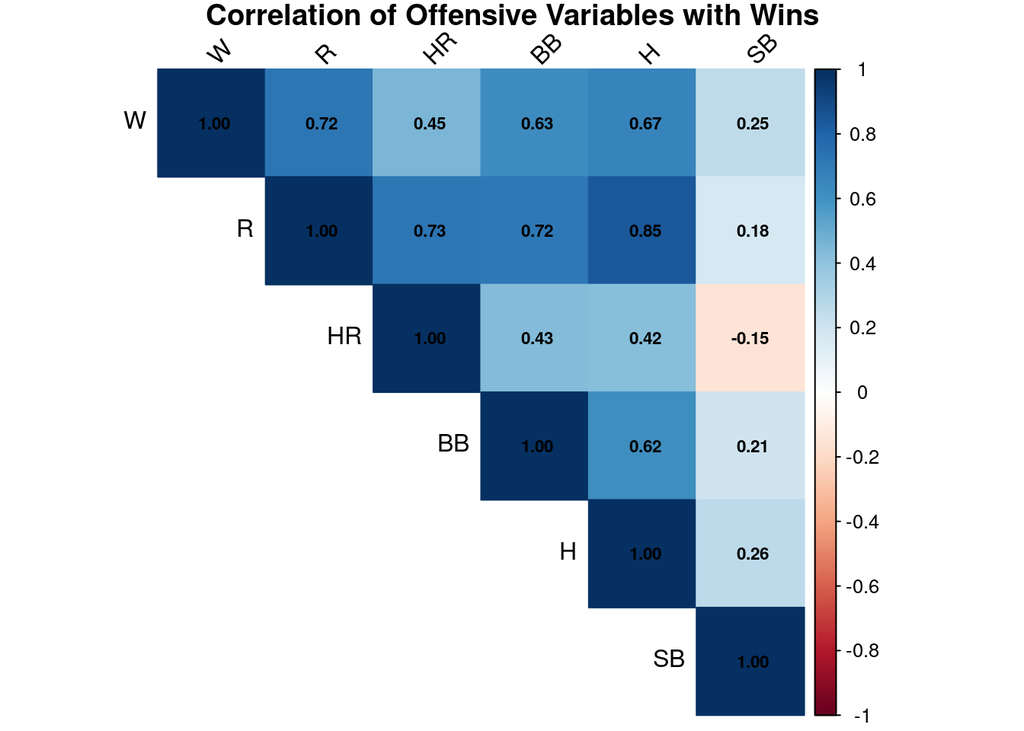

```r
# Create correlation plot for Offensive Performance Variables
corrplot(cor_offensive, method = "color", type = "upper",
         tl.col = "black", tl.srt = 45,
         addCoef.col = "black", number.cex = 0.7,
         title = "Correlation of Offensive Variables with Wins",
         mar = c(0, 0, 1, 0))
```

The correlation matrix above illustrates the offensive variables correlated with Wins. The variables most associated with wins are: R - runs scored (0.72), H - hits (0.67), and BB - walks (0.63).

```r
# Create object to hold defensive and pitching variables with Wins
defensive_vars <- Teams_filtered[, c("W", "RA", "ERA", "SOA", "SV", "FP")]
```

```r
# Calculate correlation matrices
cor_defensive <- cor(defensive_vars, use = "complete.obs")
```

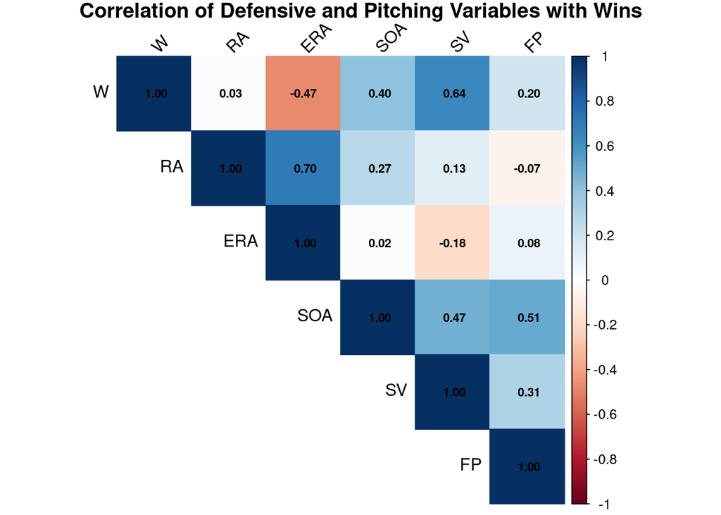

```r
# Create correlation plot for Defensive and Pitching Variables
corrplot(cor_defensive, method = "color", type = "upper",
         tl.col = "black", tl.srt = 45,
         addCoef.col = "black", number.cex = 0.7,
         title = "Correlation of Defensive and Pitching Variables with Wins",
         mar = c(0, 0, 1, 0))
```

```r
# Convert 'performance' and 'historical_success' to numeric
Teams_filtered$performance_numeric <- ifelse(Teams_filtered$performance == "Overperformed", 1, 0)
Teams_filtered$historical_success <- ifelse(Teams_filtered$WSWin == "Y", "Champion",
                                    ifelse(Teams_filtered$LgWin == "Y", "League Winner", "Non-Winner"))

# Convert historical_success to numeric encoding
Teams_filtered$historical_success_numeric <- ifelse(Teams_filtered$historical_success == "Champion", 2,
                                           ifelse(Teams_filtered$historical_success == "League Winner", 1, 0))
```

```r
# Subset data with Wins and feature-engineered variables
feature_vars <- Teams_filtered[, c("W", "run_differential", "winning_percentage",
                                    "pythagorean_expectation", "performance_numeric",
                                    "historical_success_numeric")]
```

```r
# Calculate correlation matrix with Wins included
cor_matrix <- cor(feature_vars, use = "complete.obs")
```

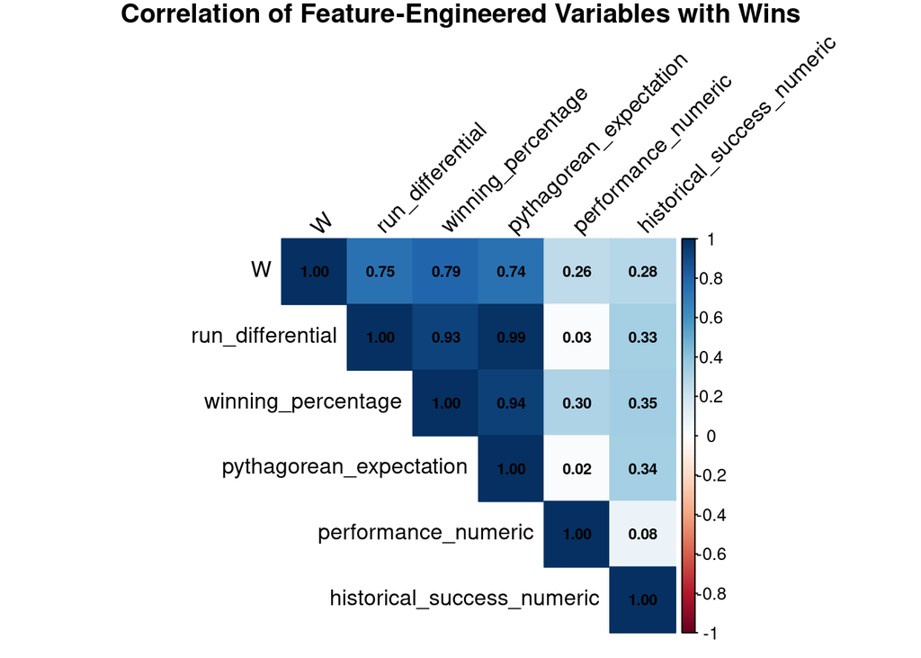

```r
# Create a plot the correlation matrix
corrplot(cor_matrix, method = "color", type = "upper",
         tl.col = "black", tl.srt = 45,
         addCoef.col = "black", number.cex = 0.7,
         title = "Correlation of Feature-Engineered Variables with Wins",
         mar = c(0, 0, 1, 0))
```

The correlation matrix above illustrates the feature engineered variables correlated with Wins. The variables most associated with wins are: run differential (0.75), winning percentage (0.79), and pythagorean expectation (0.74). These are all variables that will be taken into account for developing the predictive model for MLB wins.

# Correlation Matrix of Selected Variables

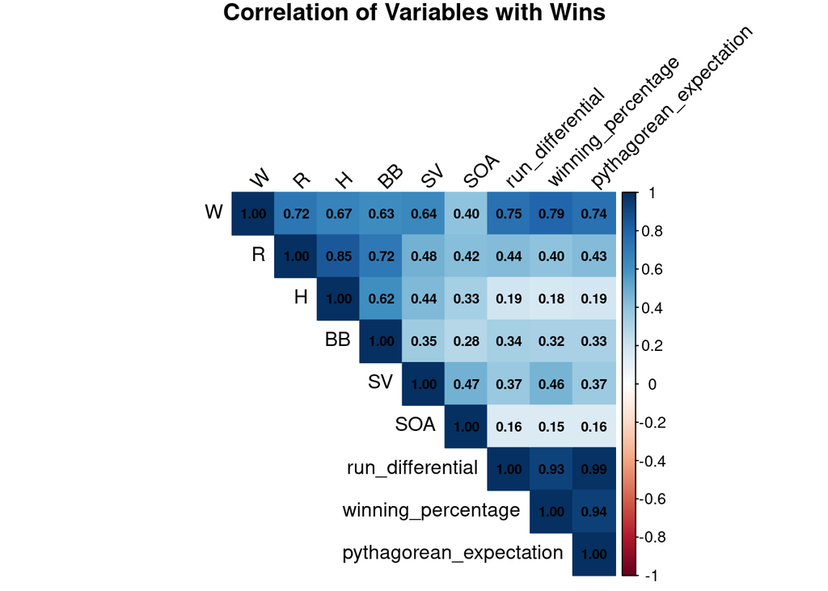

```r
correlated_vars_w <- cor(Teams_filtered %>%
                           select(W, R, H, BB, SV, SOA,
                                  run_differential,
                                  winning_percentage,
                                  pythagorean_expectation,
                                  ))

corrplot(correlated_vars_w, method = "color", type = "upper",
         tl.col = "black", tl.srt = 45,
         addCoef.col = "black", number.cex = 0.7,
         title = "Correlation of Variables with Wins",
         mar = c(0, 0, 1, 0))
```

# Train/Test

Spliting the data into train and test datasets.

```r
# Set seed for reproducibility
set.seed(123)

# Split data into training (80%) and testing (20%) sets
split_index <- createDataPartition(Teams_filtered$W, p = 0.8, list = FALSE)
train_data <- Teams_filtered[split_index, ]
test_data <- Teams_filtered[-split_index, ]
```

# Linear Regression

```r
# Fit the model
linear_model <- lm(W ~ R+ H+ BB+ SV+
                     SOA+ run_differential+
                     winning_percentage+
                     pythagorean_expectation,
                   data = train_data)

# Summarize the model
summary(linear_model)
```

```
##
## Call:
## lm(formula = W ~ R + H + BB + SV + SOA + run_differential + winning_percentage +
##     pythagorean_expectation, data = train_data)
##
## Residuals:
##      Min       1Q   Median       3Q      Max
## -11.2314  -1.7804   0.1702   1.9038   8.8944
##
## Coefficients:
##                           Estimate Std. Error t value Pr(>|t|)
## (Intercept)             -2.469e+01  4.272e+00  -5.779 9.56e-09 ***
## R                       -3.702e-02  1.793e-03 -20.645  < 2e-16 ***
## H                        4.851e-02  9.815e-04  49.426  < 2e-16 ***
## BB                       2.929e-02  1.374e-03  21.317  < 2e-16 ***
## SV                       7.623e-02  1.211e-02   6.293 4.35e-10 ***
## SOA                      8.412e-03  4.218e-04  19.944  < 2e-16 ***
## run_differential         4.382e-02  5.424e-03   8.079 1.58e-15 ***
## winning_percentage       1.423e+02  3.581e+00  39.733  < 2e-16 ***
## pythagorean_expectation -7.111e+01  8.957e+00  -7.939 4.66e-15 ***
## ---
## Signif. codes:  0 '***' 0.001 '**' 0.01 '*' 0.05 '.' 0.1 ' ' 1
##
## Residual standard error: 2.825 on 1196 degrees of freedom
## Multiple R-squared:  0.9593, Adjusted R-squared:  0.959
## F-statistic:  3526 on 8 and 1196 DF,  p-value: < 2.2e-16
```

```r
# Predict Wins on the test data
predictions <- predict(linear_model, newdata = test_data)
```

```r
# Calculate performance metrics
actual <- test_data$W
mae <- mean(abs(predictions - actual))  # Mean Absolute Error
rmse <- sqrt(mean((predictions - actual)^2))  # Root Mean Squared Error
r_squared <- 1 - (sum((predictions - actual)^2) / sum((actual - mean(actual))^2))  # R²

# Print metrics
cat("MAE:", mae, "\n")
```

```
## MAE: 2.331443
```

```r
cat("RMSE:", rmse, "\n")
```

```
## RMSE: 3.053262
```

```r
cat("R-squared:", r_squared, "\n")
```

```
## R-squared: 0.9588712
```

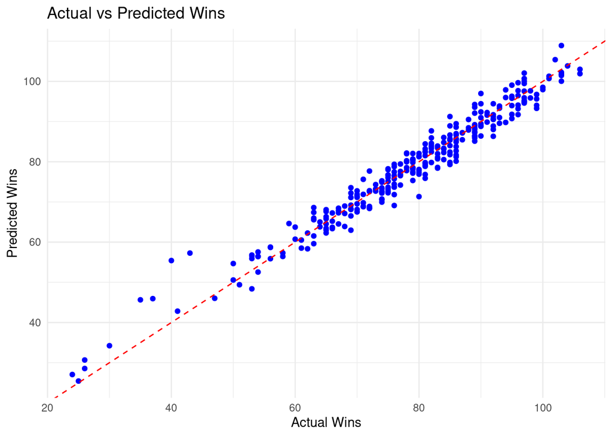

```r
# Create a scatter plot
ggplot(data = NULL, aes(x = actual, y = predictions)) +
  geom_point(color = "blue") +
  geom_abline(intercept = 0, slope = 1, color = "red", linetype = "dashed") +
  labs(title = "Actual vs Predicted Wins",
       x = "Actual Wins",
       y = "Predicted Wins") +
  theme_minimal()
```

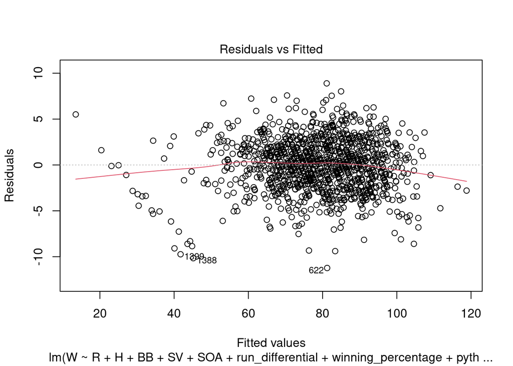

```r
# Residuals vs Fitted plot
plot(linear_model, which = 1)
```

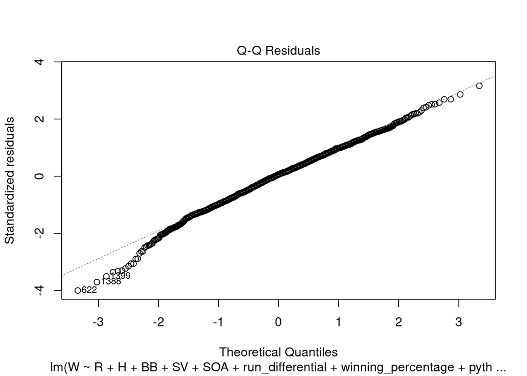

```r
# Q-Q plot to check normality
plot(linear_model, which = 2)
```

```r
# Cross-validation to validate robustness
train_control <- trainControl(method = "cv", number = 10)
cv_model <- train(W ~ R+ H+ BB+ SV+
                     SOA+ run_differential+
                     winning_percentage+
                     pythagorean_expectation,
                  data = train_data, method = "lm", trControl = train_control)
print(cv_model)
```

```
## Linear Regression
##
## 1205 samples
##    8 predictor
##
## No pre-processing
## Resampling: Cross-Validated (10 fold)
## Summary of sample sizes: 1083, 1085, 1085, 1084, 1084, 1086, ...
## Resampling results:
##
##   RMSE      Rsquared   MAE
##   2.846938  0.9576176  2.233404
##
## Tuning parameter 'intercept' was held constant at a value of TRUE
```

# Model Performance Summary Report

The goal of this assignment is to solve a problem by using one of the supervised or unsupervised machine learning algorithms taught in this course: Linear Regression, Logistic Regression, Decision Tree, K-Nearest Neighbor, K-Means Clustering, or DBSCAN.

The linear regression model’s R-squared is 0.9576, very close to 1, indicating that almost 96% of the variance in wins is explained by the model, that is the predictive variables R+ H+ BB+ SV+ SOA+ run_differential+ winning_percentage+ pythagorean_expectation).

The linear regression model’s MAE (mean absolute error) is 2.33, indicating that on average the predictions only deviate 2.33 games from the actual wins, highlighting the accuracy of the model due to its low error rate.

Overall, the linear model is an excellent fit for predicting MLB wins.

```r
# Save the model
saveRDS(linear_model, file = "mlb_wins_model.rds")
```